#### MASTER IN ARTIFICIAL INTELLIGENCE - DATA SCIENCE

# Prédiction des Consommations Énergétiques avec Réseaux de Neurones et Données Temporelles

## PROJET DE RECHERCHE IA

[figure not shown]

Présenté par Yann

### MULTI LAYER PERCEPTRON MODEL

# Chronologie des Sections et Titres du Notebook

- Introduction
- 1. Importation des bibliothèques nécessaires
- 2. Chargement et traitement du fichier CSV
- 3. Visualisation des Données
- 4. Détection des Intervalles de Données Manquantes
- 5. Pourcentage d'absence de données
- 6. Interpolation linéaire / Températures
- 7. Calcul de Corrélation
- 8. Analyse des Tendances Énergétiques
- 9. Prédiction des Valeurs Manquantes avec un Modèle de Perceptron Multicouche (MLP)
- 10. Extraction de données prédites
- 11. Ajustement des données prédites
- Principe
- Application
- Conclusion

# Introduction

Les données de consommation et de températures sont extraites depuis les plateformes de suivi des consommations d'EDF destinées aux clients tertiaires. Ces données sont récupérées via des techniques de scraping par Selenium et enregistrées sous forme de fichiers CSV. Les liens suivants sont ceux que je scrappe :

- https://expertiseconso.netseenergy.fr/
- https://inviso-interactif.dalkia.fr/pspe/
- https://iboard.netseenergy.fr/pspe/

L'objectif principal est de détecter les trous de données de consommation et de prédire les données manquantes pour combler les lacunes sur les points de mesure problématiques, où il n'est pas possible d'obtenir les données directement.

### Pourquoi le choix du MLP (Perceptron Multicouche) pour la Prédiction des Données Manquantes ?

Lors de l'analyse des méthodes disponibles pour prédire les données manquantes, plusieurs options ont été envisagées : la régression linéaire simple, la régression linéaire multivariée, et les modèles ARIMA. Cependant, le Perceptron Multicouche (MLP) a été choisi pour plusieurs raisons clés, que nous comparerons avec les autres méthodes dans le tableau ci-dessous.

### Tableau Comparatif des Méthodes

| **Critère** | **MLP (Perceptron Multicouche)** | **ARIMA** | **Régression Linéaire (Simple/Multivariée)** |
| --- | --- | --- | --- |
| **Modélisation des relations non linéaires** | Excellente capacité à capturer des relations non linéaires complexes. | Principalement adapté pour les relations linéaires, nécessite souvent des transformations pour non-linéarités. | Limité aux relations linéaires; ne peut pas modéliser efficacement les relations complexes. |
| **Robustesse face aux données manquantes** | Capacité d'apprentissage à partir de données partielles, peut gérer les données manquantes de manière plus intelligente. | Moins performant en présence de données manquantes, nécessite souvent des imputations ou des ajustements. | Nécessite des techniques d'imputation pour gérer les données manquantes, limité dans la prédiction des données absentes. |
| **Adaptabilité aux types de données** | Très adaptable, peut gérer des ensembles de données avec de nombreuses variables et des interactions complexes. | Spécifiquement conçu pour les séries temporelles stationnaires, nécessite des ajustements pour d'autres types de données. | Simple à utiliser pour les données linéaires, mais limité lorsqu'il y a plusieurs variables et interactions complexes. |
| **Complexité et Prétraitement** | Nécessite une configuration plus complexe (choix du nombre de couches, neurones, etc.), mais moins de prétraitement des données. | Nécessite des prétraitements comme la différenciation pour stationnariser les données. | Simple à mettre en œuvre, peu de prétraitement requis, mais limité en termes de modélisation des complexités des données. |
| **Capacité d'apprentissage profond** | Permet un apprentissage profond avec plusieurs couches cachées, capturant des aspects complexes des données. | Non applicable; ARIMA ne fait pas d'apprentissage profond. | Ne permet pas l'apprentissage profond, se limite à des relations simples. |
| **Flexibilité et performance** | Très flexible, peut être ajusté pour différents types de données et objectifs, avec une performance potentiellement supérieure. | Efficace pour des séries temporelles spécifiques, mais limité en flexibilité et en performance sur des données non stationnaires. | Facile à comprendre et à interpréter, mais souvent inférieur en performance pour des tâches complexes par rapport au MLP. |

### Conclusion

Le choix du MLP pour la prédiction des données manquantes est principalement motivé par sa capacité à modéliser des relations non linéaires, sa robustesse face aux données manquantes, et sa flexibilité dans le traitement de divers types de données. Alors que les modèles ARIMA et la régression linéaire offrent des solutions simples et adaptées à certaines situations, ils manquent de la complexité nécessaire pour traiter les interactions complexes et non linéaires des données de consommation énergétique. Le MLP se révèle donc être un choix plus approprié pour ce type d'analyse prédictive.

**Exemple de Dataset que je vais traiter** :

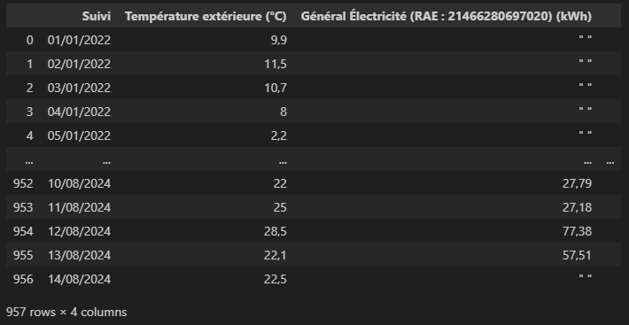

# 1. Importation des bibliothèques nécessaires

Dans ce premier bloc, je vais importer toutes les bibliothèques nécessaires.

```python
# Importation des bibliothèques nécessaires
from sklearn.metrics import mean_squared_error, mean_absolute_error, r2_score
from sklearn.model_selection import cross_val_score
from sklearn.neural_network import MLPRegressor
from sklearn.metrics import mean_squared_error
from sklearn.preprocessing import MinMaxScaler
from sklearn.ensemble import BaggingRegressor
from sklearn.dummy import DummyRegressor
import plotly.graph_objects as go
import matplotlib.pyplot as plt
import plotly.express as px
import seaborn as sns
import pandas as pd
import numpy as np
import warnings
import kaleido
import pyxnat
import joblib
import time
import os


# Suppression des avertissements pour une sortie plus propre
warnings.filterwarnings('ignore')
```

# 2. Chargement et traitement du fichier CSV

Ce bloc gère la lecture du fichier CSV, son traitement en DataFrame, et effectue les premières étapes de nettoyage.

```python
# Chemin vers le fichier CSV
file_path = 'data/Export_Volkswagen Group Retail France_Cesson - AU_COURBE kwh.csv'
```

```python
# Lecture du fichier ligne par ligne et traitement de chaque ligne
rows = []
with open(file_path, 'r', encoding='utf-8') as file:
    for line in file:
        # Diviser la ligne par le délimiteur et supprimer les espaces
        parts = line.strip().split(';')

        # Ajouter les parties séparées à la liste des lignes
        rows.append(parts)
```

```python
rows[:5]
```

```
[['\ufeffSuivi du 01/01/2022 00:00 au  27/08/2024 23:50'],
 ['Suivi', 'Température extérieure (°C)', 'Géneral Gaz (kWh)', ''],
 ['01/01/2022', '11,3', '88,56', '', '', '', ''],
 ['02/01/2022', '13', '143,88', '', '', '', ''],
 ['03/01/2022', '11,8', '237,62', '', '', '', '']]
```

```python
# Extraction de l'en-tête et vérification de la cohérence du nombre de colonnes
header = rows[1]
```

```python
data = rows[2:]   # Les données commencent à partir de la troisième ligne
# Ajuster toutes les lignes pour avoir le même nombre de colonnes que l'en-tête
adjusted_data = []
for row in data:
    if len(row) > len(header):
        row = row[:len(header)]
    elif len(row) < len(header):
        row.extend([None] * (len(header) - len(row)))
    adjusted_data.append(row)
```

```python
adjusted_data[:5]
```

```
[['01/01/2022', '11,3', '88,56', ''],
 ['02/01/2022', '13', '143,88', ''],
 ['03/01/2022', '11,8', '237,62', ''],
 ['04/01/2022', '7,4', '730,62', ''],
 ['05/01/2022', '4', '582,46', '']]
```

```python
# Conversion de la liste de lignes en DataFrame
df = pd.DataFrame(adjusted_data, columns=header)
```

```python
df[:5]
```

|  | Suivi | Température extérieure (°C) | Géneral Gaz (kWh) |  |
| --- | --- | --- | --- | --- |
| 0 | 01/01/2022 | 11,3 | 88,56 |  |
| 1 | 02/01/2022 | 13 | 143,88 |  |
| 2 | 03/01/2022 | 11,8 | 237,62 |  |
| 3 | 04/01/2022 | 7,4 | 730,62 |  |
| 4 | 05/01/2022 | 4 | 582,46 |  |

```python
# Nettoyer les en-têtes en supprimant les espaces superflus
df.columns = df.columns.str.strip()
```

```python
df.columns
```

```
Index(['Suivi', 'Température extérieure (°C)', 'Géneral Gaz (kWh)', ''], dtype='object')
```

```python
# Renommer la première colonne en "Suivi" si elle n'est pas correctement nommée
if df.columns[0] != "Suivi":
    df.rename(columns={df.columns[0]: "Suivi"}, inplace=True)
```

```python
# Détection automatique et conversion des colonnes numériques avec des virgules en float
for col in df.columns:
    if df[col].dtype == object and col != "Suivi":
        df[col] = df[col].str.replace(',', '.')
        df[col] = pd.to_numeric(df[col], errors='coerce')

# Conversion de la colonne "Suivi" au format datetime
if "Suivi" in df.columns and df["Suivi"].dtype == object:
    df["Suivi"] = pd.to_datetime(df["Suivi"].str.strip(), format="%d/%m/%Y", errors='coerce')

# Suppression des colonnes non pertinentes ou vides
df = df.dropna(axis=1, how='all')

# Affichage de la DataFrame nettoyée
print("Données nettoyées :")
df.head()
```

```
Données nettoyées :
```

|  | Suivi | Température extérieure (°C) | Géneral Gaz (kWh) |
| --- | --- | --- | --- |
| 0 | 2022-01-01 | 11.3 | 88.56 |
| 1 | 2022-01-02 | 13.0 | 143.88 |
| 2 | 2022-01-03 | 11.8 | 237.62 |
| 3 | 2022-01-04 | 7.4 | 730.62 |
| 4 | 2022-01-05 | 4.0 | 582.46 |

# 3. Visualisation des Données

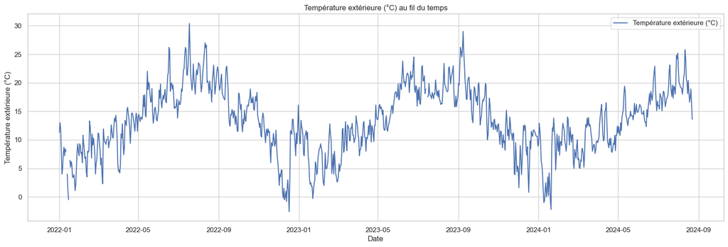

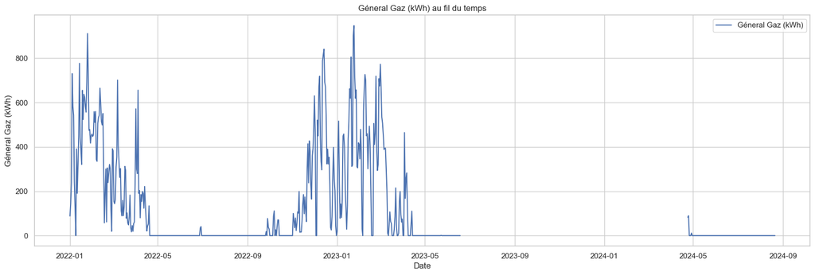

```python
# Tracé de toutes les colonnes numériques par rapport à la colonne "Suivi"
for col in df.columns:
    if col != "Suivi" and pd.api.types.is_numeric_dtype(df[col]):
        # Plotly
        fig = px.line(df, x="Suivi", y=col, title=f'{col} au fil du temps', labels={'Suivi': 'Date', col: col})
        fig.show()

        # Matplotlib
        plt.figure(figsize=(20, 6))
        plt.plot(df["Suivi"], df[col], label=col)
        plt.title(f'{col} au fil du temps')
        plt.xlabel('Date')
        plt.ylabel(col)
        plt.legend()
        plt.grid(True)
        plt.show()
```

# 4. Détection des Intervalles de Données Manquantes

Ce bloc détecte les intervalles de valeurs manquantes dans chaque colonne numérique et les affiche.

```
Tableau des intervalles manquants :
                        Column  Start Date    End Date  Missing Days
0  Température extérieure (°C)  2022-01-12  2022-01-12             1
1  Température extérieure (°C)  2022-01-16  2022-01-16             1
2  Température extérieure (°C)  2022-03-15  2022-03-15             1
3  Température extérieure (°C)  2023-07-14  2023-07-15             2
4  Température extérieure (°C)  2024-08-23  2024-08-27             5
5            Géneral Gaz (kWh)  2023-06-19  2024-04-23           310
6            Géneral Gaz (kWh)  2024-08-22  2024-08-27             6
```

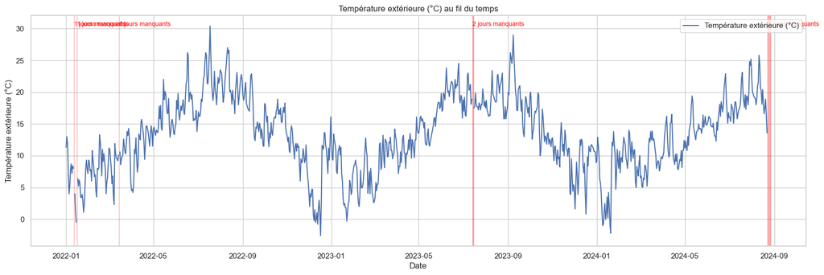

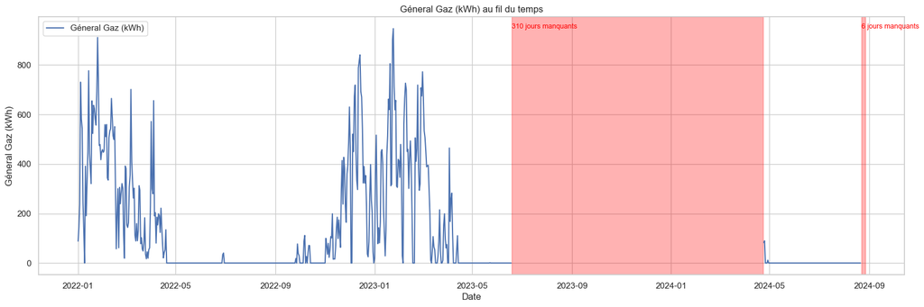

```python
def find_missing_intervals(column, date_column):
    """Trouver les intervalles de valeurs manquantes dans une colonne de DataFrame."""
    missing_intervals = []
    current_interval = None
    count_missing = 0

    for i in range(len(column)):
        if pd.isna(column[i]):
            if current_interval is None:
                current_interval = [date_column[i], date_column[i]]
            else:
                current_interval[1] = date_column[i]
            count_missing += 1
        else:
            if current_interval is not None:
                missing_intervals.append((current_interval[0], current_interval[1], count_missing))
                current_interval = None
                count_missing = 0

    if current_interval is not None:
        missing_intervals.append((current_interval[0], current_interval[1], count_missing))

    return missing_intervals

# Création d'une liste pour stocker les données des intervalles manquants
missing_intervals_data = []

# Boucle à travers chaque colonne pour trouver les intervalles manquants
for col in df.columns:
    if col != "Suivi" and pd.api.types.is_numeric_dtype(df[col]):
        missing_intervals = find_missing_intervals(df[col], df['Suivi'])
        for start, end, count in missing_intervals:
            missing_intervals_data.append({
                'Column': col,
                'Start Date': start.date(),
                'End Date': end.date(),
                'Missing Days': count
            })

# Conversion de la liste des intervalles manquants en DataFrame
missing_intervals_df = pd.DataFrame(missing_intervals_data)

# Affichage du tableau des intervalles manquants
print("Tableau des intervalles manquants :")
print(missing_intervals_df)

# Tracé de chaque colonne numérique avec les intervalles manquants mis en évidence
for col in df.columns:
    if col != "Suivi" and pd.api.types.is_numeric_dtype(df[col]):
        # Plotly
        fig = px.line(df, x="Suivi", y=col, title=f'{col} au fil du temps', labels={'Suivi': 'Date', col: col})

        # Mise en évidence des intervalles manquants dans Plotly
        for start, end, count in find_missing_intervals(df[col], df['Suivi']):
            fig.add_vrect(
                x0=start, x1=end,
                fillcolor="red", opacity=0.3,
                layer="below", line_width=0,
                annotation_text=f'{count} jours manquants', annotation_position="top left"
            )

        fig.show()

        # Matplotlib
        plt.figure(figsize=(20, 6))
        plt.plot(df["Suivi"], df[col], label=col)
        plt.title(f'{col} au fil du temps')
        plt.xlabel('Date')
        plt.ylabel(col)
        plt.legend()
        plt.grid(True)

        # Mise en évidence des intervalles manquants dans Matplotlib
        for start, end, count in find_missing_intervals(df[col], df['Suivi']):
            plt.axvspan(start, end, color='red', alpha=0.3)
            plt.text(start, max(df[col].dropna()), f'{count} jours manquants', color='red', fontsize=9)

        plt.show()
```

```python
missing_intervals_df[:10]
```

|  | Column | Start Date | End Date | Missing Days |
| --- | --- | --- | --- | --- |
| 0 | Température extérieure (°C) | 2022-01-12 | 2022-01-12 | 1 |
| 1 | Température extérieure (°C) | 2022-01-16 | 2022-01-16 | 1 |
| 2 | Température extérieure (°C) | 2022-03-15 | 2022-03-15 | 1 |
| 3 | Température extérieure (°C) | 2023-07-14 | 2023-07-15 | 2 |
| 4 | Température extérieure (°C) | 2024-08-23 | 2024-08-27 | 5 |
| 5 | Géneral Gaz (kWh) | 2023-06-19 | 2024-04-23 | 310 |
| 6 | Géneral Gaz (kWh) | 2024-08-22 | 2024-08-27 | 6 |

# 5. Pourcentage d'absence de données

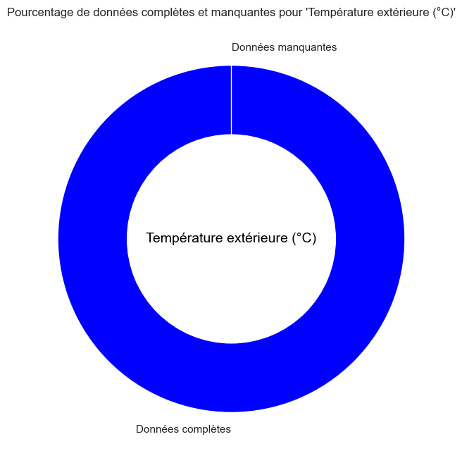

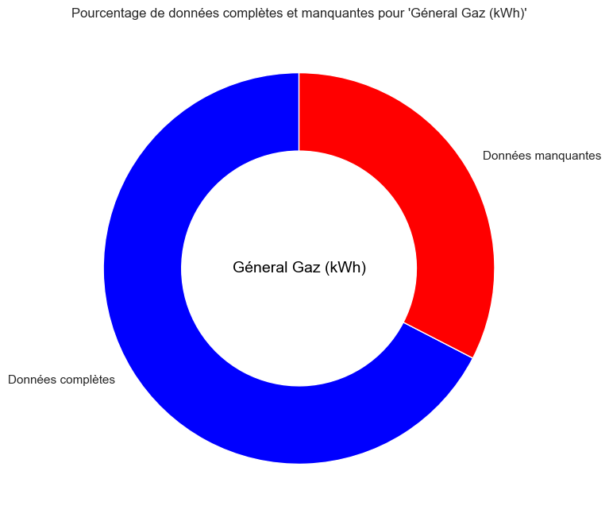

```python
# Calculer le pourcentage de données manquantes et complètes pour chaque colonne numérique
missing_percentage_data = []

for col in df.columns:
    if col != "Suivi" and pd.api.types.is_numeric_dtype(df[col]):
        total_values = len(df[col])
        missing_values = df[col].isna().sum()
        complete_values = total_values - missing_values
        missing_percentage = (missing_values / total_values) * 100
        complete_percentage = 100 - missing_percentage

        missing_percentage_data.append({
            'Column': col,
            'Missing Percentage': missing_percentage,
            'Complete Percentage': complete_percentage
        })

# Afficher le pourcentage de données manquantes et complètes pour chaque colonne sous forme de donut chart
for data in missing_percentage_data:
    # Plotly
    fig = go.Figure(data=[go.Pie(
        labels=['Données complètes', 'Données manquantes'],
        values=[data['Complete Percentage'], data['Missing Percentage']],
        hole=.5,
        marker=dict(colors=['blue', 'red'])
    )])

    fig.update_layout(
        title_text=f"Pourcentage de données complètes et manquantes pour '{data['Column']}'",
        title_y=0.95,  # Adjust title position (1.0 is the top)
        margin=dict(t=100),  # Increase top margin to provide space for the title
        annotations=[dict(text=f"{data['Column']}", x=0.5, y=0.5, font_size=14, showarrow=False)]
    )

    fig.show()

    # Matplotlib
    fig, ax = plt.subplots(figsize=(20, 8))
    ax.pie(
        [data['Complete Percentage'], data['Missing Percentage']],
        labels=['Données complètes', 'Données manquantes'],
        colors=['blue', 'red'],
        startangle=90,
        wedgeprops=dict(width=0.4)
    )

    # Ajouter le texte au centre du donut
    ax.text(0, 0, f"{data['Column']}", ha='center', va='center', fontsize=14, color='black')

    # Ajouter un titre au graphique
    plt.title(f"Pourcentage de données complètes et manquantes pour '{data['Column']}'")

    plt.show()
```

# 6. Interpolation linéaire / Températures

L'interpolation linéaire comble les valeurs manquantes en supposant une variation linéaire entre deux points connus. Mathématiquement, la valeur manquante $ y $ est estimée par la formule :

$ y = y_1 + \frac{(x - x_1)}{(x_2 - x_1)} \times (y_2 - y_1) $

où $ (x_1, y_1) $ et $ (x_2, y_2) $ sont les points adjacents connus. Cette méthode est simple et efficace pour des données continues comme la température, où les variations sont supposées progressives. De plus, les données de température sont généralement complètes, avec seulement quelques jours manquants dans l'ensemble du dataset, ce qui ne justifie pas l'utilisation de méthodes plus complexes de prédiction.

```python
# Interpolation linéaire pour remplir les valeurs manquantes dans la colonne "Température extérieure (°C)"
df['Température extérieure (°C)'] = df['Température extérieure (°C)'].interpolate(method='linear')

# Vérifier s'il reste des valeurs manquantes après l'interpolation
print(f"Valeurs manquantes après interpolation dans 'Température extérieure (°C)': {df['Température extérieure (°C)'].isna().sum()}")
```

```
Valeurs manquantes après interpolation dans 'Température extérieure (°C)': 0
```

# 7. Calcul de Corrélation

1. **Suppression des lignes avec des valeurs manquantes** :
   - Les lignes contenant des valeurs manquantes dans les colonnes "Géneral Gaz (kWh)" et "Température extérieure (°C)" sont supprimées pour obtenir un DataFrame propre (`df_clean`).
2. **Calcul de la corrélation entre la consommation énergétique et la température** :
   - Le coefficient de corrélation de Pearson entre la consommation énergétique et la température est calculé avec la formule :

   $ r = \frac{\sum \left( X_i - \overline{X} \right) \left( Y_i - \overline{Y} \right)}{\sqrt{\sum \left( X_i - \overline{X} \right)^2} \sqrt{\sum \left( Y_i - \overline{Y} \right)^2}} $

   où $ X_i $ et $ Y_i $ représentent les valeurs de la température extérieure et de la consommation énergétique, respectivement.
3. **Interprétation du coefficient de corrélation** :
   - Selon la valeur de $ r $ :
     - $ r > 0.7 $ : Forte corrélation positive.
     - $ r < -0.7 $ : Forte corrélation négative.
     - $ 0.3 < |r| \leq 0.7 $ : Corrélation modérée.
     - $ |r| \leq 0.3 $ : Faible ou absence de corrélation.
4. **Visualisation de la relation entre la consommation énergétique et la température** :
   - **Nuage de points (Scatter Plot)** : Montre la relation entre la température et la consommation.
   - **Régression linéaire** : La relation entre les deux variables est modélisée par une ligne de régression avec la formule :

   $ y = ax + b $

   où $ a $ est la pente et $ b $ est l'ordonnée à l'origine.
   - **Heatmap de corrélation** : Une matrice de corrélation montre les coefficients de corrélation entre les variables.
   - **Histogramme croisé** : Visualisation en 2D de la distribution des valeurs de température et de consommation énergétique, avec des couleurs indiquant la densité des points.

```
Le coefficient de corrélation entre la consommation énergétique et la température est : -0.76
Il existe une forte corrélation négative entre la consommation énergétique et la température.
```

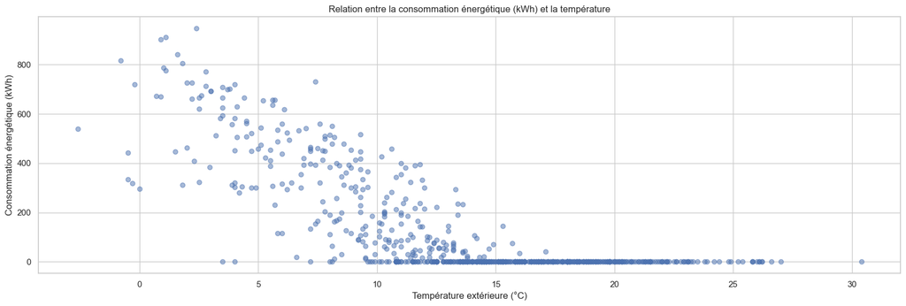

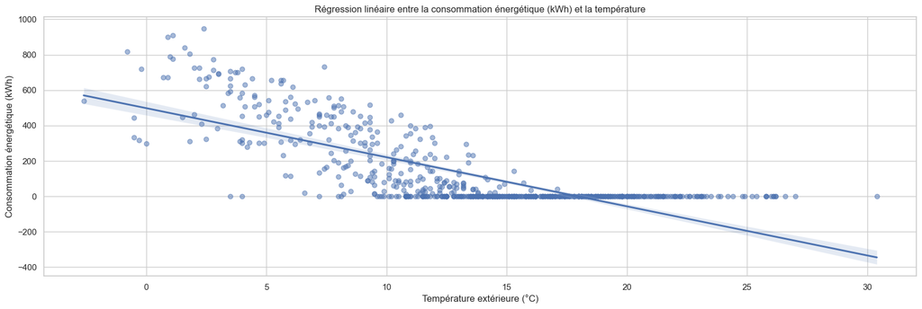

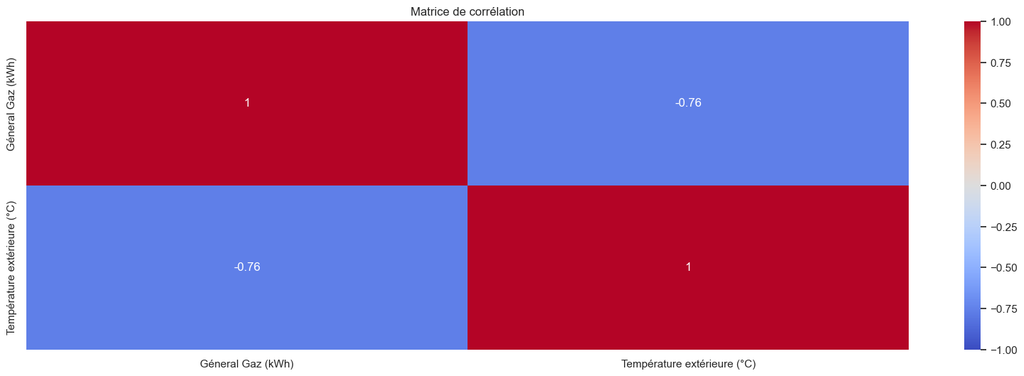

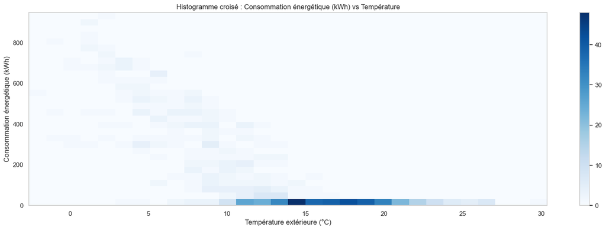

```python
# Suppression des lignes avec des valeurs manquantes dans les colonnes concernées
df_clean = df[['Géneral Gaz (kWh)', 'Température extérieure (°C)']].dropna()

# Affichage des premières lignes pour vérifier
df_clean.head()

# Calcul de la corrélation entre la consommation énergétique et la température
correlation = df_clean['Géneral Gaz (kWh)'].corr(df_clean['Température extérieure (°C)'])
print(f"Le coefficient de corrélation entre la consommation énergétique et la température est : {correlation:.2f}")

# Interprétation du coefficient de corrélation
if correlation > 0.7:
    print("Il existe une forte corrélation positive entre la consommation énergétique et la température.")
elif correlation < -0.7:
    print("Il existe une forte corrélation négative entre la consommation énergétique et la température.")
elif 0.3 < correlation <= 0.7 or -0.7 <= correlation < -0.3:
    print("Il existe une corrélation modérée entre la consommation énergétique et la température.")
else:
    print("Il existe peu ou pas de corrélation entre la consommation énergétique et la température.")

# Visualisation de la relation entre la consommation énergétique et la température

# 1. Nuage de points (Scatter Plot)
plt.figure(figsize=(20, 6))
plt.scatter(df_clean['Température extérieure (°C)'], df_clean['Géneral Gaz (kWh)'], alpha=0.5)
plt.title('Relation entre la consommation énergétique (kWh) et la température')
plt.xlabel('Température extérieure (°C)')
plt.ylabel('Consommation énergétique (kWh)')
plt.grid(True)
plt.show()

# 2. Graphique de régression linéaire avec Seaborn
plt.figure(figsize=(20, 6))
sns.regplot(x='Température extérieure (°C)', y='Géneral Gaz (kWh)', data=df_clean, scatter_kws={'alpha':0.5})
plt.title('Régression linéaire entre la consommation énergétique (kWh) et la température')
plt.xlabel('Température extérieure (°C)')
plt.ylabel('Consommation énergétique (kWh)')
plt.grid(True)
plt.show()

# 3. Heatmap de corrélation
corr_matrix = df_clean.corr()
plt.figure(figsize=(20, 6))
sns.heatmap(corr_matrix, annot=True, cmap='coolwarm', vmin=-1, vmax=1)
plt.title('Matrice de corrélation')
plt.show()

# 4. Histogramme croisé
plt.figure(figsize=(20, 6))
plt.hist2d(df_clean['Température extérieure (°C)'], df_clean['Géneral Gaz (kWh)'], bins=30, cmap='Blues')
plt.colorbar()
plt.title('Histogramme croisé : Consommation énergétique (kWh) vs Température')
plt.xlabel('Température extérieure (°C)')
plt.ylabel('Consommation énergétique (kWh)')
plt.show()
```

# 8. Analyse des Tendances Énergétiques

### 1. **Classification des tendances**

- La fonction `classify_trends` calcule la tendance jour à jour d'une colonne spécifique du DataFrame (ici "Géneral Gaz (kWh)"). Elle utilise la différence entre les jours consécutifs pour déterminer si la tendance est haussière (+1), baissière (-1), ou stable (0).

### 2. **Détection des intervalles de données manquantes**

- La fonction `find_missing_intervals` identifie les périodes où les données sont manquantes dans une colonne donnée. Elle renvoie les intervalles de dates où les valeurs sont absentes.

### 3. **Analyse détaillée des tendances**

- **Distribution des tendances par jour de la semaine et par mois** :
  - Les tendances sont analysées et visualisées sous forme de graphiques en barres empilées, montrant comment les tendances varient selon le jour de la semaine et le mois.
- **Visualisation des valeurs originales et des données manquantes** :
  - Un graphique linéaire montre les valeurs de la consommation énergétique au fil du temps. Les intervalles de données manquantes sont mis en évidence par des rubans rouges, avec le nombre de jours manquants indiqué.
- **Calcul et visualisation des moyennes de consommation** :
  - Les moyennes de consommation énergétique sont calculées pour chaque jour de la semaine, chaque mois, et chaque année. Ces moyennes sont ensuite visualisées sous forme de "donut charts" (graphiques circulaires), montrant la distribution de la consommation.

### 4. **Classement de la consommation énergétique**

- Les jours de la semaine, les mois, et les années sont classés en fonction de la consommation énergétique moyenne, et les résultats sont affichés pour identifier les périodes de consommation les plus élevées.

En résumé, ce code permet de classifier les tendances de consommation énergétique, de détecter et visualiser les données manquantes, d'analyser les tendances selon les jours, les mois, et les années, et de classer ces périodes selon la consommation moyenne.

[figure not shown]

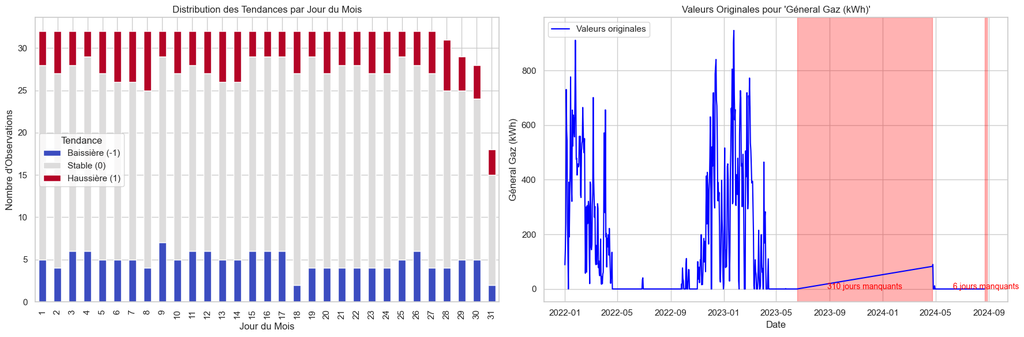

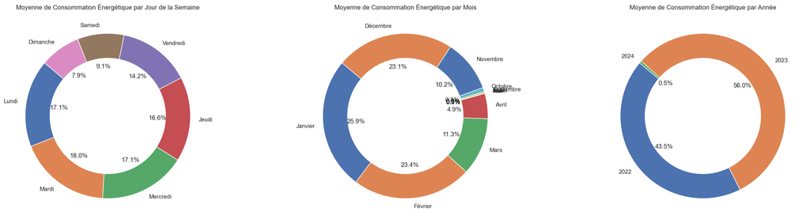

```
Classement des jours de la semaine selon la consommation énergétique moyenne :
Weekday
1    159.427419
0    151.518495
2    151.102340
3    146.937742
4    125.790108
5     80.720957
6     70.336277
Name: Géneral Gaz (kWh), dtype: float64

Classement des mois selon la consommation énergétique moyenne :
Month
1     427.793871
2     385.674464
12    381.039032
3     186.926452
11    168.427667
4      81.500896
10     13.207419
9       5.443333
6       0.958333
5       0.012366
7       0.000000
8       0.000000
Name: Géneral Gaz (kWh), dtype: float64

Classement des années selon la consommation énergétique moyenne :
Suivi
2023    182.194970
2022    141.670438
2024      1.533333
Name: Géneral Gaz (kWh), dtype: float64
```

```python
def classify_trends(df, column_name):
    """Classifie les tendances en fonction de la variation jour à jour."""
    df['Trend'] = np.sign(df[column_name].diff().fillna(0))
    return df

def find_missing_intervals(df, date_column, value_column):
    """Trouver les intervalles de valeurs manquantes dans une colonne de DataFrame."""
    missing_intervals = []
    current_interval = None

    for i in range(len(df)):
        if pd.isna(df.iloc[i][value_column]):
            if current_interval is None:
                current_interval = [df.iloc[i][date_column], df.iloc[i][date_column]]
            else:
                current_interval[1] = df.iloc[i][date_column]
        else:
            if current_interval is not None:
                missing_intervals.append(current_interval)
                current_interval = None

    if current_interval is not None:
        missing_intervals.append(current_interval)

    return missing_intervals

def detailed_trend_analysis(df, column_name):
    # Analyser la distribution des tendances par jour de la semaine, mois, et jour du mois
    df['Weekday'] = df['Suivi'].dt.weekday
    df['Month'] = df['Suivi'].dt.month
    df['Day'] = df['Suivi'].dt.day

    day_of_week_trends = df.groupby(['Weekday', 'Trend']).size().unstack().fillna(0)
    month_trends = df.groupby(['Month', 'Trend']).size().unstack().fillna(0)
    day_trends = df.groupby(['Day', 'Trend']).size().unstack().fillna(0)

    # Configurer les graphiques avec Seaborn
    sns.set(style="whitegrid")

    # Graphique pour les tendances par jour de la semaine et par mois
    fig, axes = plt.subplots(1, 2, figsize=(18, 6))

    day_of_week_trends.plot(kind='bar', stacked=True, colormap='coolwarm', ax=axes[0])
    axes[0].set_title("Distribution des Tendances par Jour de la Semaine")
    axes[0].set_xlabel("Jour de la Semaine")
    axes[0].set_ylabel("Nombre d'Observations")
    axes[0].set_xticks(range(7))
    axes[0].set_xticklabels(["Lundi", "Mardi", "Mercredi", "Jeudi", "Vendredi", "Samedi", "Dimanche"], rotation=45)
    axes[0].legend(title="Tendance", labels=['Baissière (-1)', 'Stable (0)', 'Haussière (1)'])
    axes[0].grid(True)

    month_trends.plot(kind='bar', stacked=True, colormap='coolwarm', ax=axes[1])
    axes[1].set_title("Distribution des Tendances par Mois")
    axes[1].set_xlabel("Mois")
    axes[1].set_ylabel("Nombre d'Observations")
    axes[1].set_xticks(range(1, 13))
    axes[1].set_xticklabels(["Janvier", "Février", "Mars", "Avril", "Mai", "Juin", "Juillet", "Août", "Septembre", "Octobre", "Novembre", "Décembre"], rotation=45)
    axes[1].legend(title="Tendance", labels=['Baissière (-1)', 'Stable (0)', 'Haussière (1)'])
    axes[1].grid(True)

    plt.tight_layout()
    plt.show()

    # Graphique pour les tendances par jour du mois et les valeurs originales avec ruban rouge pour les données manquantes
    fig, axes = plt.subplots(1, 2, figsize=(18, 6))

    day_trends.plot(kind='bar', stacked=True, colormap='coolwarm', ax=axes[0])
    axes[0].set_title("Distribution des Tendances par Jour du Mois")
    axes[0].set_xlabel("Jour du Mois")
    axes[0].set_ylabel("Nombre d'Observations")
    axes[0].legend(title="Tendance", labels=['Baissière (-1)', 'Stable (0)', 'Haussière (1)'])
    axes[0].grid(True)

    sns.lineplot(data=df, x='Suivi', y=column_name, label='Valeurs originales', color='blue', ax=axes[1])

    # Ajouter des rubans rouges pour les données manquantes avec le nombre de jours manquants
    missing_intervals = find_missing_intervals(df, 'Suivi', column_name)
    for start, end in missing_intervals:
        axes[1].axvspan(start, end, color='red', alpha=0.3)
        num_missing_days = (end - start).days + 1
        mid_date = start + (end - start) / 2
        axes[1].text(mid_date, df[column_name].min(), f'{num_missing_days} jours manquants',
                     color='red', fontsize=10, ha='center')

    axes[1].set_title(f"Valeurs Originales pour '{column_name}'")
    axes[1].set_xlabel('Date')
    axes[1].set_ylabel(column_name)
    axes[1].legend()
    axes[1].grid(True)

    plt.tight_layout()
    plt.show()

    # Calcul de la moyenne de consommation par jour de la semaine, mois, et année
    weekday_mean = df.groupby('Weekday')[column_name].mean()
    month_mean = df.groupby('Month')[column_name].mean()
    year_mean = df.groupby(df['Suivi'].dt.year)[column_name].mean()

    # Création des donut charts pour la moyenne de consommation, tous en ligne
    fig, axes = plt.subplots(1, 3, figsize=(24, 6))

    axes[0].pie(weekday_mean, labels=["Lundi", "Mardi", "Mercredi", "Jeudi", "Vendredi", "Samedi", "Dimanche"], autopct='%1.1f%%', startangle=140, wedgeprops=dict(width=0.3))
    axes[0].set_title("Moyenne de Consommation Énergétique par Jour de la Semaine")

    axes[1].pie(month_mean, labels=["Janvier", "Février", "Mars", "Avril", "Mai", "Juin", "Juillet", "Août", "Septembre", "Octobre", "Novembre", "Décembre"], autopct='%1.1f%%', startangle=140, wedgeprops=dict(width=0.3))
    axes[1].set_title("Moyenne de Consommation Énergétique par Mois")

    axes[2].pie(year_mean, labels=year_mean.index, autopct='%1.1f%%', startangle=140, wedgeprops=dict(width=0.3))
    axes[2].set_title("Moyenne de Consommation Énergétique par Année")

    plt.tight_layout()
    plt.show()

    # Classement des jours selon la consommation énergétique moyenne
    weekday_ranking = weekday_mean.sort_values(ascending=False)
    month_ranking = month_mean.sort_values(ascending=False)
    year_ranking = year_mean.sort_values(ascending=False)

    print("Classement des jours de la semaine selon la consommation énergétique moyenne :")
    print(weekday_ranking)

    print("\nClassement des mois selon la consommation énergétique moyenne :")
    print(month_ranking)

    print("\nClassement des années selon la consommation énergétique moyenne :")
    print(year_ranking)

# Exemple d'utilisation
if __name__ == "__main__":
    # Appliquer la classification des tendances
    df = classify_trends(df, 'Géneral Gaz (kWh)')

    # Réaliser l'analyse détaillée des tendances et créer les donut charts
    detailed_trend_analysis(df, 'Géneral Gaz (kWh)')
```

# 9. Prédiction des Valeurs Manquantes avec un Modèle de Perceptron Multicouche (MLP)

Dans cette section, nous utilisons un modèle de Perceptron Multicouche (MLP) pour prédire les valeurs manquantes dans les colonnes contenant "kWh". Nous incluons également la température comme variable explicative.

### Input Layer

Neurons: 4

1. Température extérieure (°C)
2. Mois (Month)
3. Jour (Day)
4. Jour de la semaine (Weekday)

Normalization: MinMaxScaler

Ici, les données sont préparées en fonction des variables explicatives et normalisées avant de les passer à travers le modèle.

### Hidden Layer 1

Neurons: 100

Activation: ReLU

f(x) = max(0, x)

Cette couche applique la fonction d'activation ReLU f(x) = max(0, x) pour introduire la non-linéarité.

### Hidden Layer 2

Neurons: 100

Activation: ReLU

La deuxième couche cachée continue de transformer les données avec ReLU pour capturer des relations complexes.

### Output Layer

Neurons: 1

Output: Energy Consumption (kWh)

Cette couche produit la prédiction finale de la consommation énergétique.

### Training & Evaluation

Optimizer: Adam

Learning Rate: 0.001

Loss Function: MSE

Evaluation Metrics:

- RMSE
- MAE
- R²

Cross-Validation: 5-Fold

Optimisation et évaluation du modèle à l'aide des métriques et techniques mentionnées.

[figure not shown]

```
Baseline RMSE pour Géneral Gaz (kWh): 182.64065974643148
Baseline MAE pour Géneral Gaz (kWh): 128.19706663832503
Baseline R² pour Géneral Gaz (kWh): 0.0
Modèle sauvegardé sous le nom : Export_DESAUTEL_Meyzieu_COURBE_model.pkl
Train RMSE pour Géneral Gaz (kWh): 114.4279253073664
Train MAE pour Géneral Gaz (kWh): 63.378913571059044
Train R² pour Géneral Gaz (kWh): 0.6074733814103488
Cross-validation RMSE pour Géneral Gaz (kWh): 181.55844831784003
Le modèle pour Géneral Gaz (kWh) est performant selon les critères définis par rapport au modèle de base.
```

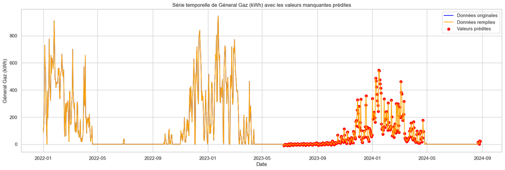

```
Valeurs prédites pour Géneral Gaz (kWh) :
          Date  Valeurs prédites
534 2023-06-19        -10.503831
535 2023-06-20         -5.919268
536 2023-06-21         -0.674621
537 2023-06-22          0.044265
538 2023-06-23         -1.675738
..         ...               ...
965 2024-08-23          9.676052
966 2024-08-24          5.583826
967 2024-08-25          0.985182
968 2024-08-26         24.309040
969 2024-08-27         21.537537

[316 rows x 2 columns]
```

```python
# S'assurer que la colonne de température est bien nommée
temperature_column = "Température extérieure (°C)"

# Extraction des colonnes contenant "kWh"
kwh_columns = [col for col in df.columns if "kWh" in col]

for kwh_col in kwh_columns:
    data = df[['Suivi', kwh_col, temperature_column]].copy()

    # Stocker les données manquantes avec les dates respectives
    missing_data = data[data[kwh_col].isna()]

    # Remplir temporairement les valeurs manquantes pour l'analyse
    data_filled = data.copy()
    data_filled.fillna(method='ffill', inplace=True)

    # Création des variables explicatives (ex. : caractéristiques temporelles)
    data_filled['Month'] = data_filled['Suivi'].dt.month
    data_filled['Day'] = data_filled['Suivi'].dt.day
    data_filled['Weekday'] = data_filled['Suivi'].dt.weekday

    # Normalisation des variables explicatives
    scaler = MinMaxScaler()
    explanatory_vars = ['Month', 'Day', 'Weekday', temperature_column]
    data_filled[explanatory_vars] = scaler.fit_transform(data_filled[explanatory_vars])

    # Préparation du jeu de données pour le perceptron
    X = data_filled[explanatory_vars].values
    y = data_filled[kwh_col].values

    # Supprimer les lignes où y contient des valeurs NaN
    valid_rows = ~np.isnan(y)
    X = X[valid_rows]
    y = y[valid_rows]

    # 1. Baseline Model: Dummy Regressor
    baseline_model = DummyRegressor(strategy="mean")
    baseline_model.fit(X, y)

    baseline_predictions = baseline_model.predict(X)
    baseline_rmse = np.sqrt(mean_squared_error(y, baseline_predictions))
    baseline_mae = mean_absolute_error(y, baseline_predictions)
    baseline_r2 = r2_score(y, baseline_predictions)

    print(f"Baseline RMSE pour {kwh_col}: {baseline_rmse}")
    print(f"Baseline MAE pour {kwh_col}: {baseline_mae}")
    print(f"Baseline R² pour {kwh_col}: {baseline_r2}")

    # 2. Définition et entraînement du modèle Bagging Ensemble avec MLP
    mlp = MLPRegressor(hidden_layer_sizes=(100, 100), max_iter=1000, random_state=42)
    bagging_model = BaggingRegressor(base_estimator=mlp, n_estimators=20, random_state=42)
    bagging_model.fit(X, y)

    # Sauvegarde du modèle
    csv_file_name = "Export_DESAUTEL_Meyzieu_COURBE.csv"
    model_file_name = f"{os.path.splitext(csv_file_name)[0]}_model.pkl"
    joblib.dump(bagging_model, model_file_name)
    print(f"Modèle sauvegardé sous le nom : {model_file_name}")

    # Évaluer la performance du modèle
    train_predictions = bagging_model.predict(X)
    train_rmse = np.sqrt(mean_squared_error(y, train_predictions))
    train_mae = mean_absolute_error(y, train_predictions)
    train_r2 = r2_score(y, train_predictions)

    # Cross-validation
    cross_val_scores = cross_val_score(bagging_model, X, y, cv=5, scoring='neg_mean_squared_error')
    cross_val_rmse = np.sqrt(-cross_val_scores.mean())

    # Affichage des résultats
    print(f"Train RMSE pour {kwh_col}: {train_rmse}")
    print(f"Train MAE pour {kwh_col}: {train_mae}")
    print(f"Train R² pour {kwh_col}: {train_r2}")
    print(f"Cross-validation RMSE pour {kwh_col}: {cross_val_rmse}")

    # 3. Evaluation automatique du modèle
    if train_rmse < baseline_rmse and train_r2 > baseline_r2 and train_mae < baseline_mae:
        print(f"Le modèle pour {kwh_col} est performant selon les critères définis par rapport au modèle de base.")
    else:
        print(f"Le modèle pour {kwh_col} n'est pas performant selon les critères définis par rapport au modèle de base.")

    # Ajouter les variables explicatives aux données manquantes
    if not missing_data.empty:
        missing_data['Month'] = missing_data['Suivi'].dt.month
        missing_data['Day'] = missing_data['Suivi'].dt.day
        missing_data['Weekday'] = missing_data['Suivi'].dt.weekday
        missing_data[explanatory_vars] = scaler.transform(missing_data[explanatory_vars])

        # Prédiction des valeurs manquantes
        missing_indexes = missing_data['Suivi']
        missing_explanatory_vars = missing_data[explanatory_vars].values
        predicted_missing_values = bagging_model.predict(missing_explanatory_vars)

        # Remplir les valeurs manquantes avec les prédictions
        df.loc[df['Suivi'].isin(missing_indexes), kwh_col] = predicted_missing_values

        # Tracer la série temporelle originale et remplie avec Plotly
        fig = go.Figure()
        fig.add_trace(go.Scatter(x=data['Suivi'], y=data[kwh_col], mode='lines', name='Données originales', line=dict(color='blue')))
        fig.add_trace(go.Scatter(x=df['Suivi'], y=df[kwh_col], mode='lines', name='Données remplies', line=dict(color='orange')))
        fig.add_trace(go.Scatter(x=missing_indexes, y=predicted_missing_values, mode='markers', name='Valeurs prédites', marker=dict(color='red')))
        fig.update_layout(title=f"Série temporelle de {kwh_col} avec les valeurs manquantes prédites",
                          xaxis_title="Date", yaxis_title=f"{kwh_col}")
        fig.show()

        # Tracer la série temporelle originale et remplie avec Matplotlib
        plt.figure(figsize=(20, 6))
        plt.plot(data['Suivi'], data[kwh_col], label='Données originales', color='blue')
        plt.plot(df['Suivi'], df[kwh_col], label='Données remplies', color='orange')
        plt.scatter(missing_indexes, predicted_missing_values, label='Valeurs prédites', color='red')
        plt.title(f"Série temporelle de {kwh_col} avec les valeurs manquantes prédites")
        plt.xlabel("Date")
        plt.ylabel(kwh_col)
        plt.legend()
        plt.grid(True)
        plt.show()

        # Afficher les valeurs prédites
        predicted_df = pd.DataFrame({'Date': missing_indexes, 'Valeurs prédites': predicted_missing_values})
        print(f"Valeurs prédites pour {kwh_col} :")
        print(predicted_df)
    else:
        print(f"Aucune donnée manquante pour la colonne {kwh_col}.")
```

# 10. Extraction de données prédites

1. **Crée le dossier `CONSO_PRED`** s'il n'existe pas.
2. **Prépare un DataFrame** pour chaque colonne de consommation (kWh), en y ajoutant la date, les valeurs, et une colonne indiquant si la valeur a été prédite.
3. **Remplace les valeurs négatives par zéro**.
4. **Sauvegarde le DataFrame** en fichier Excel dans le dossier `CONSO_PRED`.

```python
# Vérifier ou créer le dossier CONSO_PRED
output_folder = 'CONSO_PRED'
if not os.path.exists(output_folder):
    os.makedirs(output_folder)

for kwh_col in kwh_columns:
    # Création du DataFrame pour l'exportation
    prediction_df = df[['Suivi', kwh_col]].copy()
    prediction_df.rename(columns={'Suivi': 'Date', kwh_col: 'Valeurs'}, inplace=True)

    # Ajouter la colonne 'Predicted (yes/no)'
    prediction_df['Predicted (yes/no)'] = np.where(prediction_df['Valeurs'].isin(predicted_missing_values), 'yes', 'no')

    # Remplacer les valeurs négatives par zéro dans la colonne 'Valeurs'
    prediction_df['Valeurs'] = prediction_df['Valeurs'].apply(lambda x: max(x, 0))

    # Enregistrer sous forme de fichier Excel
    excel_file_name = f"{output_folder}/{kwh_col}_JOUR_PREDICTIONS.xlsx"
    prediction_df.to_excel(excel_file_name, index=False)

    print(f"Fichier Excel généré et sauvegardé sous : {excel_file_name}")
```

```
Fichier Excel généré et sauvegardé sous : CONSO_PRED/Géneral Gaz (kWh)_JOUR_PREDICTIONS.xlsx
```

```python
# Vérifier ou créer le dossier CONSO_PRED
output_folder = 'CONSO_PRED'
if not os.path.exists(output_folder):
    os.makedirs(output_folder)

for kwh_col in kwh_columns:
    # Création du DataFrame pour l'exportation
    prediction_df = df[['Suivi', kwh_col]].copy()
    prediction_df.rename(columns={'Suivi': 'Date', kwh_col: 'Valeurs'}, inplace=True)

    # Ajouter la colonne 'Predicted (yes/no)'
    prediction_df['Predicted (yes/no)'] = np.where(prediction_df['Valeurs'].isin(predicted_missing_values), 'yes', 'no')

    # Remplacer les valeurs négatives par zéro dans la colonne 'Valeurs'
    prediction_df['Valeurs'] = prediction_df['Valeurs'].apply(lambda x: max(x, 0))

    # Calculer le nombre de valeurs prédites par année
    prediction_df['Year'] = prediction_df['Date'].dt.year
    predicted_per_year = prediction_df[prediction_df['Predicted (yes/no)'] == 'yes'].groupby('Year').size()

    # Calculer le score de confiance (par exemple R² du modèle)
    confidence_score = r2_score(y, train_predictions)

    # Enregistrer les résultats dans un fichier Excel
    excel_file_name = f"{output_folder}/{kwh_col}_JOUR_PREDICTIONS.xlsx"
    prediction_df.to_excel(excel_file_name, index=False)


    # Evaluation du score de confiance
    if confidence_score > 0.8:
        confidence_evaluation = "Très bon score de confiance."
    elif 0.6 <= confidence_score <= 0.8:
        confidence_evaluation = "Bon score de confiance."
    elif 0.4 <= confidence_score < 0.6:
        confidence_evaluation = "Score acceptable de confiance."
    else:
        confidence_evaluation = "Faible score de confiance. Le modèle pourrait être amélioré."

    print(f"Fichier Excel généré et sauvegardé sous : {excel_file_name}")
    print(f"Nombre de valeurs prédites par année pour {kwh_col} :")
    print(predicted_per_year)
    print(f"Score de confiance (R²) pour {kwh_col} : {confidence_score:.4f} ({confidence_evaluation})")
```

```
Fichier Excel généré et sauvegardé sous : CONSO_PRED/Géneral Gaz (kWh)_JOUR_PREDICTIONS.xlsx
Nombre de valeurs prédites par année pour Géneral Gaz (kWh) :
Year
2023    196
2024    120
dtype: int64
Score de confiance (R²) pour Géneral Gaz (kWh) : 0.6075 (Bon score de confiance.)
```

1. **Analyse des tendances :**
   - Les tendances de consommation sont classées par jour de la semaine, mois, et jour du mois, puis visualisées sous forme de graphiques en barres empilées.
2. **Visualisation des valeurs originales et prédites :**
   - Un graphique linéaire est tracé pour montrer les valeurs originales de la consommation énergétique, avec les valeurs prédites mises en évidence en rouge.
3. **Formules mathématiques :**
   - La classification des tendances est basée sur la différence des valeurs entre les jours consécutifs, en utilisant la formule :

$ \text{Trend} = \text{sign}(V_{t} - V_{t-1}) $

où $V_{t} $ est la valeur de la consommation à un jour donné.

Ce code est utilisé pour comprendre les tendances de consommation énergétique en fonction du temps et pour visualiser les données prédictives par rapport aux valeurs réelles.

[output not shown]

[figure not shown]

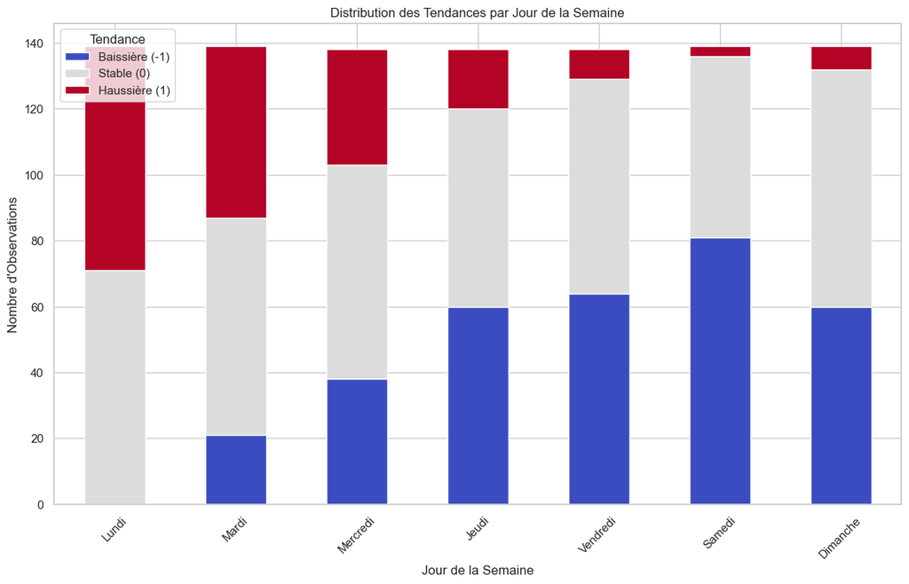

[figure not shown]

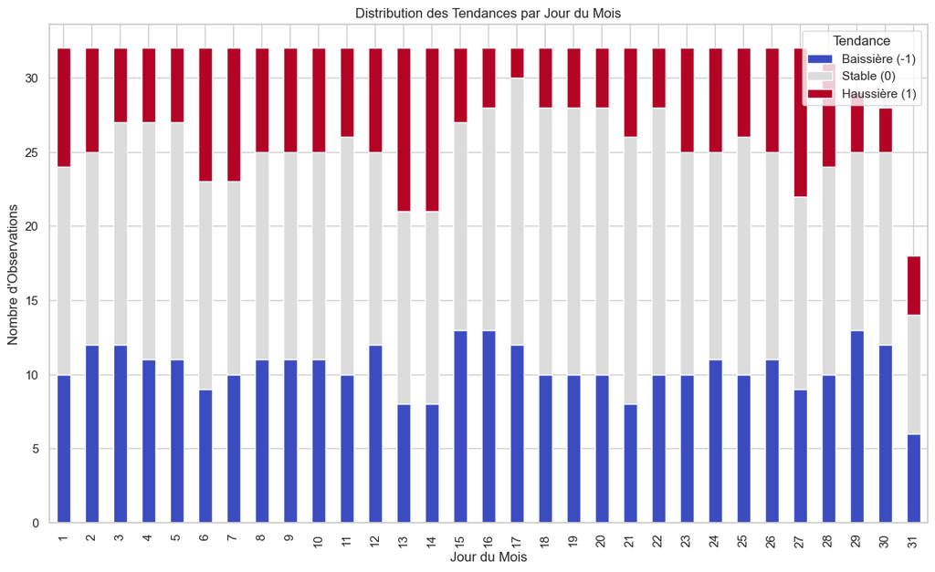

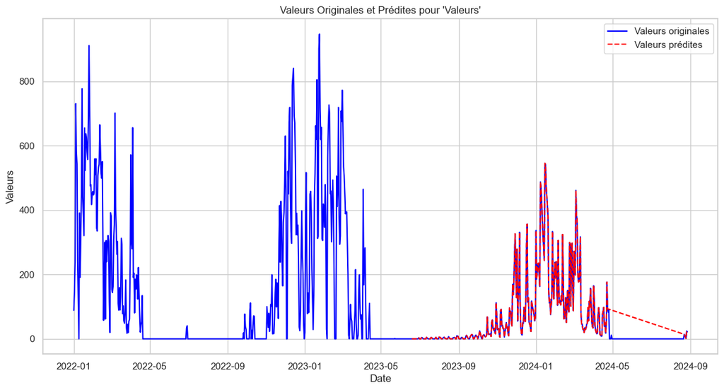

```python
def detailed_trend_analysis(df, column_name):
    # Analyser la distribution des tendances par jour de la semaine, mois, et jour du mois
    day_of_week_trends = df.groupby(['Weekday', 'Predicted_Trend']).size().unstack().fillna(0)
    month_trends = df.groupby(['Month', 'Predicted_Trend']).size().unstack().fillna(0)
    day_trends = df.groupby(['Day', 'Predicted_Trend']).size().unstack().fillna(0)

    # Configurer les graphiques avec Seaborn
    sns.set(style="whitegrid")

    # Graphique pour les tendances par jour de la semaine
    plt.figure(figsize=(14, 8))
    day_of_week_trends.plot(kind='bar', stacked=True, colormap='coolwarm', ax=plt.gca())
    plt.title("Distribution des Tendances par Jour de la Semaine")
    plt.xlabel("Jour de la Semaine")
    plt.ylabel("Nombre d'Observations")
    plt.xticks(ticks=range(7), labels=["Lundi", "Mardi", "Mercredi", "Jeudi", "Vendredi", "Samedi", "Dimanche"], rotation=45)
    plt.legend(title="Tendance", labels=['Baissière (-1)', 'Stable (0)', 'Haussière (1)'])
    plt.grid(True)

    # Graphique pour les tendances par mois
    plt.figure(figsize=(14, 8))
    month_trends.plot(kind='bar', stacked=True, colormap='coolwarm', ax=plt.gca())
    plt.title("Distribution des Tendances par Mois")
    plt.xlabel("Mois")
    plt.ylabel("Nombre d'Observations")
    plt.xticks(ticks=range(1, 13), labels=["Janvier", "Février", "Mars", "Avril", "Mai", "Juin", "Juillet", "Août", "Septembre", "Octobre", "Novembre", "Décembre"], rotation=45)
    plt.legend(title="Tendance", labels=['Baissière (-1)', 'Stable (0)', 'Haussière (1)'])
    plt.grid(True)

    # Graphique pour les tendances par jour du mois
    plt.figure(figsize=(14, 8))
    day_trends.plot(kind='bar', stacked=True, colormap='coolwarm', ax=plt.gca())
    plt.title("Distribution des Tendances par Jour du Mois")
    plt.xlabel("Jour du Mois")
    plt.ylabel("Nombre d'Observations")
    plt.legend(title="Tendance", labels=['Baissière (-1)', 'Stable (0)', 'Haussière (1)'])
    plt.grid(True)

    # Ajouter une ligne pour les valeurs prédictes
    plt.figure(figsize=(14, 7))
    sns.lineplot(data=df, x='Date', y=column_name, label='Valeurs originales', color='blue')

    # Highlight predicted values
    predicted_df = df[df['Predicted (yes/no)'] == 'yes']
    sns.lineplot(data=predicted_df, x='Date', y=column_name, label='Valeurs prédites', color='red', linestyle='--')

    plt.title(f"Valeurs Originales et Prédites pour '{column_name}'")
    plt.xlabel('Date')
    plt.ylabel(column_name)
    plt.legend()
    plt.grid(True)
    plt.show()

# Exemple d'utilisation
if __name__ == "__main__":
    # Charger le fichier Excel
    excel_file_path = 'CONSO_PRED/Géneral Gaz (kWh)_JOUR_PREDICTIONS.xlsx'
    df = pd.read_excel(excel_file_path)

    # Appliquer la classification des tendances (si ce n'est pas déjà fait)
    df_classified = classify_trends(df, 'Valeurs')

    # Réaliser l'analyse détaillée des tendances
    detailed_trend_analysis(df_classified, 'Valeurs')
```

# 11. Ajustement des données prédites

[output not shown]

[figure not shown]

```
Dates et valeurs dans la période spécifiée (2023-06-07 à 2023-09-18):
          Date   Valeurs Predicted (yes/no)
522 2023-06-07  0.000000                 no
523 2023-06-08  0.000000                 no
524 2023-06-09  0.000000                 no
525 2023-06-10  0.000000                 no
526 2023-06-11  0.000000                 no
..         ...       ...                ...
621 2023-09-14  8.640593                yes
622 2023-09-15  3.734325                yes
623 2023-09-16  0.911334                yes
624 2023-09-17  0.000000                yes
625 2023-09-18  0.000000                yes

[104 rows x 3 columns]
Somme des valeurs prédictes: 162.42
Somme des valeurs non prédictes: 0.00
Facteur de mise à l'échelle calculé: 23.0951
Nouvelle somme des valeurs prédictes après ajustement: 3750.93
Nouvelle somme totale (prédites + non prédictes) après ajustement: 3750.93
```

[figure not shown]

```
Fichier Excel avec ajustements enregistré sous : CONSO_PRED\Valeurs_JOUR_ADJUSTED.xlsx
```

```python
def adjust_predictions_to_sum(df, start_date, end_date, target_sum, column_name):
    # Vérifier que les colonnes nécessaires existent
    required_columns = ['Date', column_name, 'Predicted (yes/no)']
    for col in required_columns:
        if col not in df.columns:
            raise ValueError(f"La colonne '{col}' est manquante dans le DataFrame.")

    # Filtrer les données pour la période spécifiée par l'utilisateur
    period_df = df[(df['Date'] >= start_date) & (df['Date'] <= end_date)].copy()

    # Afficher toutes les dates et valeurs dans la période spécifiée
    print(f"Dates et valeurs dans la période spécifiée ({start_date.date()} à {end_date.date()}):")
    print(period_df[['Date', column_name, 'Predicted (yes/no)']])

    # Calculer la somme des valeurs prédite et non prédite
    sum_predicted = period_df[period_df['Predicted (yes/no)'] == 'yes'][column_name].sum()
    sum_non_predicted = period_df[period_df['Predicted (yes/no)'] == 'no'][column_name].sum()

    print(f"Somme des valeurs prédictes: {sum_predicted:.2f}")
    print(f"Somme des valeurs non prédictes: {sum_non_predicted:.2f}")

    # Calculer la somme totale nécessaire pour ajuster les valeurs prédictes
    required_sum_predicted = target_sum - sum_non_predicted

    # Filtrer les valeurs où 'Predicted (yes/no)' est 'yes'
    predicted_df = period_df[period_df['Predicted (yes/no)'] == 'yes'].copy()

    # Si aucune valeur prédite n'est trouvée, avertir mais continuer
    if predicted_df.empty:
        print(f"Aucune valeur prédite trouvée dans la période spécifiée ({start_date} à {end_date}). Aucune modification ne sera apportée.")
        return df

    # Calculer le facteur de mise à l'échelle pour les valeurs prédictes
    scaling_factor = required_sum_predicted / sum_predicted
    print(f"Facteur de mise à l'échelle calculé: {scaling_factor:.4f}")

    # Appliquer le facteur de mise à l'échelle avec une légère variation stochastique
    np.random.seed(42)  # Pour la reproductibilité
    stochastic_variation = np.random.normal(loc=1.0, scale=0.02, size=len(predicted_df))
    predicted_df[column_name] = predicted_df[column_name] * scaling_factor * stochastic_variation

    # Mettre à jour le DataFrame original avec les valeurs ajustées
    df.update(predicted_df)

    # Vérifier la nouvelle somme après ajustement
    final_sum_predicted = df[(df['Date'] >= start_date) & (df['Date'] <= end_date) & (df['Predicted (yes/no)'] == 'yes')][column_name].sum()
    final_sum_non_predicted = df[(df['Date'] >= start_date) & (df['Date'] <= end_date) & (df['Predicted (yes/no)'] == 'no')][column_name].sum()
    final_sum_total = final_sum_predicted + final_sum_non_predicted

    print(f"Nouvelle somme des valeurs prédictes après ajustement: {final_sum_predicted:.2f}")
    print(f"Nouvelle somme totale (prédites + non prédictes) après ajustement: {final_sum_total:.2f}")

    # Tracer les résultats avec des couleurs différentes
    plt.figure(figsize=(12, 6))
    # Valeurs non prédictes (non ajustées)
    plt.plot(period_df[period_df['Predicted (yes/no)'] == 'no']['Date'],
             period_df[period_df['Predicted (yes/no)'] == 'no'][column_name],
             label='Valeurs non prédictes', color='blue')

    # Valeurs prédictes ajustées
    plt.plot(period_df[period_df['Predicted (yes/no)'] == 'yes']['Date'],
             period_df[period_df['Predicted (yes/no)'] == 'yes'][column_name],
             label='Valeurs prédictes ajustées', color='orange')

    plt.title(f"Ajustement des valeurs prédictes de {start_date.date()} à {end_date.date()}")
    plt.xlabel('Date')
    plt.ylabel(column_name)
    plt.legend()
    plt.grid(True)
    plt.show()

    # Enregistrer le DataFrame ajusté dans un fichier Excel
    output_folder = 'CONSO_PRED'
    os.makedirs(output_folder, exist_ok=True)
    excel_file_name = os.path.join(output_folder, f"{column_name}_JOUR_ADJUSTED.xlsx")
    df.to_excel(excel_file_name, index=False)
    print(f"Fichier Excel avec ajustements enregistré sous : {excel_file_name}")

    return df

# Exemple d'utilisation pour l'ajustement
if __name__ == "__main__":
    # Charger le fichier Excel
    excel_file_path = 'CONSO_PRED/Géneral Gaz (kWh)_JOUR_PREDICTIONS.xlsx'
    df = pd.read_excel(excel_file_path)

    # Définir les dates de début et de fin par défaut
    start_date = pd.to_datetime('2023-06-07')
    end_date = pd.to_datetime('2023-09-18')

    # Permettre à l'utilisateur de changer les dates par défaut
    user_input = input(f"Voulez-vous utiliser les dates par défaut ({start_date.date()} à {end_date.date()})? (oui/non): ").strip().lower()
    if user_input == 'non':
        start_date_input = input("Veuillez entrer la nouvelle date de début (au format AAAA-MM-JJ) : ")
        end_date_input = input("Veuillez entrer la nouvelle date de fin (au format AAAA-MM-JJ) : ")
        start_date = pd.to_datetime(start_date_input)
        end_date = pd.to_datetime(end_date_input)

    # Définir la somme cible et le nom de la colonne à ajuster
    target_sum = 3751  # Somme cible donnée par le client
    column_to_adjust = 'Valeurs'  # Nom de la colonne à ajuster

    # Appliquer la classification des tendances
    df_classified = classify_trends(df, column_to_adjust)

    # Appeler la fonction d'ajustement
    df_adjusted = adjust_predictions_to_sum(df_classified, start_date, end_date, target_sum, column_to_adjust)
```

# Principe

Réseau de neurones multi-couches :

### 1. **Normalisation des Variables Explicatives (MinMaxScaler)**

#### Principe Mathématique :

La **normalisation** est une technique que j'utilise pour redimensionner les valeurs des caractéristiques (features) afin qu'elles se situent dans un intervalle donné, généralement $[0, 1]$. Pour chaque caractéristique $ x $ de l'ensemble de données, je calcule la normalisation comme suit :

$$x' = \frac{x - \text{min}(x)}{\text{max}(x) - \text{min}(x)}$$

où :

- $x$ est la valeur d'origine,
- $\text{min}(x)$ est la valeur minimale de la caractéristique $x$,
- $\text{max}(x)$ est la valeur maximale de la caractéristique $x$.

Cette étape est importante dans les réseaux de neurones, car elle garantit que toutes les caractéristiques sont sur une échelle comparable, ce qui aide à la convergence du modèle pendant l'entraînement.

### 2. **Réseau de Neurones Multi-Couches (MLP - Multilayer Perceptron)**

#### Principe Mathématique :

Je construis un **réseau de neurones multi-couches (MLP)**, un modèle d'apprentissage profond composé de plusieurs couches de neurones, où chaque neurone d'une couche est connecté à chaque neurone de la couche suivante.

L'équation de base pour un neurone dans une couche cachée est la suivante :

$$h_j = f\left(\sum_{i} w_{ij}x_i + b_j\right)$$

où :

- $h_j$ est la sortie du neurone $j$ dans la couche cachée,
- $x_i$ sont les entrées du neurone $j$,
- $w_{ij}$ sont les poids associés à chaque connexion entre les neurones $i$ et $j$,
- $b_j$ est le biais ajouté au neurone $j$,
- $f$ est la fonction d'activation (souvent une fonction non linéaire comme ReLU ou sigmoid).

#### Utilisation de la Fonction d'Activation ReLU :

Dans le modèle MLP, j'utilise la **fonction d'activation ReLU (Rectified Linear Unit)** dans les couches cachées. La fonction ReLU est définie par :

$$f(x) = \max(0, x)$$

Cette fonction prend comme entrée la somme pondérée des entrées du neurone plus le biais, et renvoie soit cette valeur directement si elle est positive, soit 0 si elle est négative. Ce comportement simple mais puissant permet d'introduire la non-linéarité dans le modèle, ce qui est essentiel pour que le réseau de neurones puisse apprendre des relations complexes dans les données.

La ReLU présente plusieurs avantages :

- **Non-linéarité** : Elle permet au modèle de capturer des relations non-linéaires dans les données, ce qui est souvent nécessaire pour des tâches complexes.
- **Simplicité** : Elle est computationnellement efficace à calculer et à optimiser.
- **Évite le problème du gradient vanishing** : Contrairement à d'autres fonctions d'activation comme la sigmoïde ou la tangente hyperbolique, ReLU ne souffre pas du problème de gradient vanishing, ce qui rend l'entraînement des réseaux de neurones plus profond plus efficace.

La ReLU est appliquée à chaque neurone dans les couches cachées du MLP, ce qui permet au modèle de mieux généraliser sur des données complexes.

### 3. **Bagging Regressor (Bagging Ensemble avec MLP)**

#### Principe Mathématique :

Pour améliorer la stabilité et la précision des modèles d'apprentissage machine, j'utilise le **Bagging** (Bootstrap Aggregating), une technique d'ensemble qui combine les prédictions de plusieurs modèles entraînés sur des sous-ensembles différents du même jeu de données.

Les étapes sont les suivantes :

1. Je crée plusieurs sous-ensembles de données en échantillonnant avec remise à partir du jeu de données d'origine.
2. J'entraîne un modèle (ici, un MLP) sur chaque sous-ensemble.
3. Je combine les prédictions de tous les modèles par moyenne (pour une régression) pour obtenir la prédiction finale.

L'objectif est de réduire la variance du modèle et d'améliorer la généralisation. Mathématiquement, si $ \hat{f}_i(x) $ représente la prédiction du $ i^{\text{ème}} $ modèle, la prédiction finale est donnée par :

$$\hat{f}(x) = \frac{1}{M} \sum_{i=1}^{M} \hat{f}_i(x)$$

où $M$ est le nombre de modèles.

### 4. **Metrics d'Évaluation (RMSE, MAE, R²)**

#### RMSE (Root Mean Squared Error):

Pour évaluer la précision de mes prédictions, j'utilise le **RMSE**, qui est une mesure de l'erreur quadratique moyenne entre les valeurs prédites et les valeurs réelles. Il est calculé comme suit :

$$\text{RMSE} = \sqrt{\frac{1}{n} \sum_{i=1}^{n} (y_i - \hat{y}_i)^2}$$

où :

- $y_i$ est la valeur réelle,
- $\hat{y}_i$ est la valeur prédite,
- $n$ est le nombre d'observations.

Le RMSE me donne une idée de la magnitude des erreurs de prédiction en termes de l'échelle des valeurs observées.

#### MAE (Mean Absolute Error):

Je mesure également l'erreur absolue moyenne (MAE), qui est la moyenne des erreurs absolues entre les valeurs prédites et les valeurs réelles. Elle est calculée comme suit :

$$\text{MAE} = \frac{1}{n} \sum_{i=1}^{n} |y_i - \hat{y}_i|$$

Le MAE est une mesure plus robuste aux outliers que le RMSE car il ne donne pas un poids quadratique aux erreurs.

#### R² (Coefficient de Détermination):

Je calcule également le **R²** pour évaluer quelle proportion de la variance de la variable dépendante est expliquée par le modèle. Il est calculé comme suit :

$$R^2 = 1 - \frac{\sum_{i=1}^{n} (y_i - \hat{y}_i)^2}{\sum_{i=1}^{n} (y_i - \bar{y})^2}$$

où $\bar{y}$ est la moyenne des valeurs réelles $y_i$. Un $R²$ proche de 1 indique que le modèle explique bien la variance des données.

### 5. **Cross-Validation (Validation Croisée)**

#### Principe Mathématique :

Pour évaluer la performance de mon modèle de manière plus générale, j'utilise la **validation croisée**. Dans la validation croisée $k$-fold, les données sont divisées en $k$ sous-ensembles ou "folds". Le modèle est entraîné sur $k-1$ folds et validé sur le fold restant. Ce processus est répété $k$ fois, chaque fold étant utilisé exactement une fois comme ensemble de validation. Le score final est la moyenne des scores des $k$ validations.

Mathématiquement, si $E_i$ est l'erreur sur le $i^{\text{ème}}$ fold, l'erreur de validation croisée est :

$$E_{CV} = \frac{1}{k} \sum_{i=1}^{k} E_i$$

Cette technique m'aide à évaluer la performance du modèle de manière plus générale et à éviter le surapprentissage (overfitting).

### 6. **Modèle Baseline (Dummy Regressor)**

#### Principe Mathématique :

Je commence souvent par un **modèle de baseline** pour établir une référence. Le `DummyRegressor` que j'utilise dans ce code est un modèle qui prédit simplement la moyenne des valeurs cibles dans l'ensemble d'entraînement. Cela donne une performance de référence que le modèle plus complexe (ici, MLP avec bagging) doit dépasser.

Le `DummyRegressor` calcule les prédictions comme suit :

$$\hat{y} = \frac{1}{n} \sum_{i=1}^{n} y_i$$

où $y_i$ sont les valeurs cibles réelles.

### Conclusion

En combinant ces concepts, j'ai mis en œuvre une approche robuste pour prédire les valeurs manquantes dans une série temporelle en utilisant un modèle de réseau de neurones avec bagging. J'ai comparé les performances à un modèle de référence simple et j'ai utilisé des techniques de validation croisée pour évaluer la généralisation du modèle.

# Application

Calcul pour démonstration.

### 1. **Normalisation des Variables Explicatives (MinMaxScaler)**

#### Exemple avec des données :

Supposons que j'ai les données suivantes pour la température extérieure et les mois :

$ \begin{array}{|c|c|} \hline \text{Température extérieure (°C)} & \text{Mois} \\ \hline 15.2 & 1 \\ 10.5 & 2 \\ 18.7 & 3 \\ 12.3 & 4 \\ 21.4 & 5 \\ \hline \end{array} $

La normalisation des valeurs de température sur une échelle de 0 à 1 se fait en appliquant la formule suivante :

$ x' = \frac{x - \text{min}(x)}{\text{max}(x) - \text{min}(x)} $

Voici comment cela se calcule :

- $\text{min}(x) = 10.5$
- $\text{max}(x) = 21.4$

Ainsi, toutes les valeurs de la température sont maintenant normalisées entre 0 et 1.

### 2. **Réseau de Neurones Multi-Couches (MLP - Multilayer Perceptron)**

#### Exemple avec des données simulées :

Ces données vont être utilisées pour entraîner un MLP. Le MLP pourrait avoir la structure suivante :

- **Input Layer**: 2 neurones (Température normalisée, Mois)
- **Hidden Layer 1**: 4 neurones (avec activation ReLU)
- **Hidden Layer 2**: 4 neurones (avec activation ReLU)
- **Output Layer**: 1 neurone (Consommation (kWh))

#### Utilisation de la Fonction d'Activation ReLU :

Dans le modèle MLP, j'utilise la **fonction d'activation ReLU (Rectified Linear Unit)** dans les couches cachées. La fonction ReLU est définie par :

$ f(x) = \max(0, x) $

La ReLU prend comme entrée la somme pondérée des entrées du neurone plus le biais, et renvoie soit cette valeur directement si elle est positive, soit 0 si elle est négative. Par exemple, si une somme pondérée d'entrées plus le biais vaut $-2.5$, la sortie de la ReLU sera $0$, tandis que si elle vaut $3.4$, la sortie sera $3.4$.

ReLU est appliqué pour introduire de la non-linéarité, ce qui permet au modèle d'apprendre des relations complexes.

#### Exemple de Calcul avec ReLU :

Supposons que dans une couche cachée, nous ayons un neurone avec les entrées suivantes après pondération et ajout du biais :

$ z = 0.7 \times \text{Température normalisée} + 0.2 \times \text{Mois} + 0.1 $

En appliquant la fonction ReLU :

$ h = \max(0, 0.4141) = 0.4141 $

Si le résultat de $z$ était négatif, par exemple $-0.4141$, la sortie de ReLU aurait été $0$.

### 3. **Bagging Regressor (Bagging Ensemble avec MLP)**

#### Exemple avec des données :

En appliquant le Bagging Regressor, j'entraîne plusieurs modèles MLP sur des sous-ensembles de ces données. Supposons que j'utilise 5 modèles ${n\_estimators=5}$. Chaque modèle pourrait voir un sous-ensemble légèrement différent des données d'origine (en raison de l'échantillonnage avec remise).

La prédiction finale pour une entrée donnée est obtenue en moyennant les prédictions des 5 modèles. Si les prédictions des 5 modèles pour une entrée donnée sont 120.0, 121.5, 119.8, 120.7, et 121.0, alors la prédiction finale sera :

$ \hat{f}(x) = \frac{120.0 + 121.5 + 119.8 + 120.7 + 121.0}{5} \approx 120.6 \text{ kWh} $

### 4. **Metrics d'Évaluation (RMSE, MAE, R²)**

#### Exemple avec des résultats d'entraînement :

Supposons que mon modèle prédit les valeurs suivantes pour la consommation (kWh) :

$ \begin{array}{|c|c|} \hline \text{Consommation réelle (kWh)} & \text{Consommation prédite (kWh)} \\ \hline 120.5 & 120.6 \\ 115.2 & 114.8 \\ 130.3 & 129.7 \\ 118.7 & 119.0 \\ 135.4 & 136.2 \\ \hline \end{array} $

Les métriques d'évaluation sont calculées comme suit :

- **RMSE** :

$ \text{RMSE} = \sqrt{\frac{1}{5} \left((120.5 - 120.6)^2 + (115.2 - 114.8)^2 + \ldots \right)} $

- **MAE** :

$ \text{MAE} = \frac{1}{5} \left(|120.5 - 120.6| + |115.2 - 114.8| + \ldots \right) $

- **R²** : Supposons que la moyenne des valeurs réelles soit $ \bar{y} = 124.02 $, alors :

$ R^2 = 1 - \frac{\sum_{i=1}^{5} (y_i - \hat{y}_i)^2}{\sum_{i=1}^{5} (y_i - \bar{y})^2} $

### 5. **Cross-Validation (Validation Croisée)**

#### Exemple d'application :

Supposons que j'utilise la validation croisée avec $ k=3 $. Les données sont divisées en trois ensembles :

Le modèle est entraîné trois fois, chaque fois sur un ensemble différent. La performance du modèle est la moyenne des performances sur les trois folds.

### 6. **Modèle Baseline (Dummy Regressor)**

#### Exemple d'application :

Supposons que le Dummy Regressor prédit simplement la moyenne des valeurs cibles dans l'ensemble d'entraînement. Si la moyenne des valeurs cibles dans l'ensemble est $ \bar{y} = 124.02 $ kWh, alors le Dummy Regressor prédira cette valeur pour toutes les entrées. Les performances de ce modèle seront évaluées avec les mêmes métriques (RMSE, MAE, R²) et comparées à celles du modèle MLP avec Bagging pour juger de son efficacité.

### Conclusion

# Conclusion

En remplissant les valeurs manquantes grâce aux prédictions de notre modèle, nous avons amélioré la complétude de l'ensemble de données, ce qui est essentiel pour des analyses plus approfondies. Les étapes suivies dans ce notebook constituent une base solide pour des tâches prédictives plus avancées.

Ce travail montre l'efficacité du MLP et du Bagging dans la gestion des ensembles de données incomplets et ouvre la voie à des analyses prédictives plus complexes.